# Reproducible Research: Peer Assessment 1

## Step 1: Loading and preprocessing the data

Let’s first load the data and make sure that the observations in each column is of the right class.

```r
library (dplyr)
library (lubridate)
data <- read.csv("activity.csv", header = TRUE, colClasses = "character")


data %>%
  mutate (date = as.Date (date)) %>%
  mutate (steps = as.integer(steps)) %>%
  mutate (interval = as.integer (interval)) -> data
  head (data)
```

```
##   steps       date interval
## 1    NA 2012-10-01        0
## 2    NA 2012-10-01        5
## 3    NA 2012-10-01       10
## 4    NA 2012-10-01       15
## 5    NA 2012-10-01       20
## 6    NA 2012-10-01       25
```

## Step 2: What is mean total number of steps taken per day?

Now let’s look at the data, especially the total numbers of steps taken by the test subject.

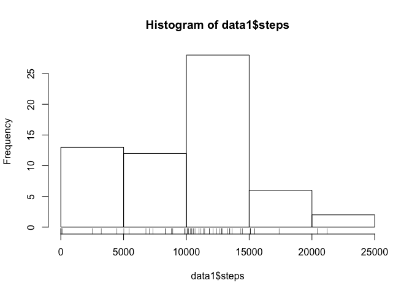

```r
#calculate the total steps per day
data %>%
  group_by (date) %>%
  summarize (steps = sum (steps, na.rm = TRUE)) -> data1

#make a histogram
hist (data1$steps)
rug (data1$steps)
```

```r
#return the mean and median values
summary (data1$steps)
```

```
##    Min. 1st Qu.  Median    Mean 3rd Qu.    Max.
##       0    6778   10395    9354   12811   21194
```

Voila! Now we know the mean and the median of the total steps taken per day.

## Step 3: What is the average daily activity pattern?

Okay, now let’s look at the daily activity pattern, by investigating how the total steps increases in 5 mins intervals

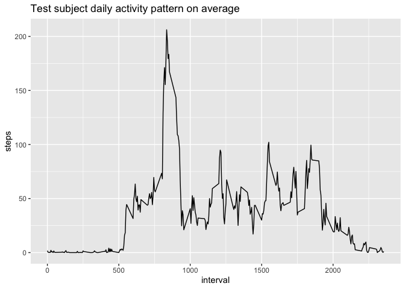

```r
library (ggplot2)

#format the data and calculate the mean steps for each interval averaged by days
data %>%
  select (interval, steps) %>%
  group_by (interval) %>%
  summarize (steps = mean(steps, na.rm = TRUE)) -> data2

#plot the daily activity pattern
    ggplot (data2, aes (interval, steps)) +
      geom_line () +
      labs (title  = "Test subject daily activity pattern on average")
```

## Step 4: Imputing missing values

Now, we noticed that there are quite a few missing values in our observations. Next we will impute these missing values by replacing the NAs with the mean steps of that 5-min interval.

```r
#calculate the total of NAs
id <- is.na(data$steps)
sum(id)
```

```
## [1] 2304
```

```r
#the distribution of NA data is even across the intervals
table(data$interval[id])
```

```
##
##    0    5   10   15   20   25   30   35   40   45   50   55  100  105  110  115
##    8    8    8    8    8    8    8    8    8    8    8    8    8    8    8    8
##  120  125  130  135  140  145  150  155  200  205  210  215  220  225  230  235
##    8    8    8    8    8    8    8    8    8    8    8    8    8    8    8    8
##  240  245  250  255  300  305  310  315  320  325  330  335  340  345  350  355
##    8    8    8    8    8    8    8    8    8    8    8    8    8    8    8    8
##  400  405  410  415  420  425  430  435  440  445  450  455  500  505  510  515
##    8    8    8    8    8    8    8    8    8    8    8    8    8    8    8    8
##  520  525  530  535  540  545  550  555  600  605  610  615  620  625  630  635
##    8    8    8    8    8    8    8    8    8    8    8    8    8    8    8    8
##  640  645  650  655  700  705  710  715  720  725  730  735  740  745  750  755
##    8    8    8    8    8    8    8    8    8    8    8    8    8    8    8    8
##  800  805  810  815  820  825  830  835  840  845  850  855  900  905  910  915
##    8    8    8    8    8    8    8    8    8    8    8    8    8    8    8    8
```

[output cut: 22 more lines]

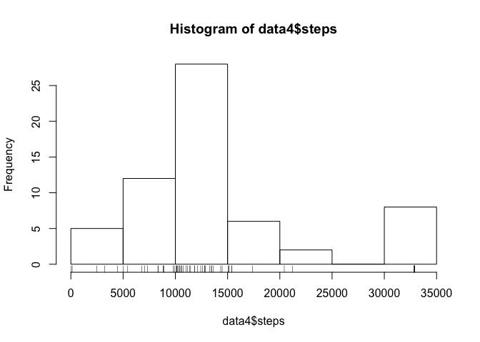

```r
#filling in all the NAs in the data set with their interval means
  data[id,]%>%
   group_by (interval) %>%
   arrange (interval) -> df

  temp <- vector ("numeric")

for (i in 1:nrow(data2)) {

  temp <- c(temp, rep (data2$steps[i], times = 8))
}

    as.matrix(df) %>%
    cbind (temp) -> data3

    as.data.frame(data3) %>%
      select (temp, date, interval) -> data3

    names (data3) <- c("steps", "date", "interval")

    data3$steps <- as.numeric (data3$steps)
    data3$date <- as.Date(data3$date)
    data3$interval <- as.numeric (data3$interval)

    data[!id,] %>%
      bind_rows (data3) -> data3

#compute the mean and median total of the total steps which the test
#subject has taken per day

data3 %>%
  group_by (date) %>%
  summarize (steps = sum(steps)) -> data4

hist (data4$steps)
rug(data4$steps)
```

```r
summary (data4$steps)
```

```
##    Min. 1st Qu.  Median    Mean 3rd Qu.    Max.
##      41    9819   11458   13665   15084   32873
```

So, what if we use another imputing method? Let’s impute the missing values by replacing the NAs with the mean steps of that day. How different will the imputed data set look?

```r
#filling in all the NAs in the data set with their day means
#pull all the NA observations from the raw data
  data[id,]%>%
   group_by (date) %>%
   arrange (date) -> df

#observe that the NA observations are evenly distributed across the days
table (df$date)
```

```
##
## 2012-10-01 2012-10-08 2012-11-01 2012-11-04 2012-11-09 2012-11-10 2012-11-14
##        288        288        288        288        288        288        288
## 2012-11-30
##        288
```

```r
#calculate the mean steps by days
  data %>%
    group_by(date) %>%
    summarize (steps = mean(steps, na.rm = TRUE)) -> data5

#replace the NAN results with 0s
  for (i in 1:nrow(data5)) {
    if (is.nan(data5$steps[i])) {
      data5$steps[i] <- 0
    }
  }

#save the day means in a temp vector
  temp <- vector ("numeric")
  for (i in 1:nrow(data5)) {

  temp <- c(temp, rep (data5$steps[i], times = 288))
  }

#replace the NAs with temp in df
    as.matrix(df) %>%
    cbind (temp) -> data6
```

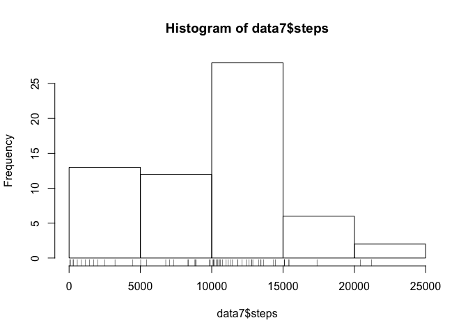

```r
    as.data.frame(data6) %>%
      select (temp, date, interval) -> data6

    names (data6) <- c("steps", "date", "interval")

    data6$steps <- as.numeric (data6$steps)
    data6$date <- as.Date(data6$date)
    data6$interval <- as.numeric (data6$interval)

#bind the imputed observations with the rest of the dataframe
    data[!id,] %>%
      bind_rows (data6) -> data6

#compute the mean and median total of the total steps which the test
#subject has taken per day

  data6 %>%
  group_by (date) %>%
  summarize (steps = sum(steps)) -> data7

hist (data7$steps)
rug(data7$steps)
```

```r
summary (data7$steps)
```

```
##    Min. 1st Qu.  Median    Mean 3rd Qu.    Max.
##      41    6778   10395    9491   12811   21194
```

Comparing the two imputing methods with the data summary and histogram of the original data, it is clear that the second imputing method, replacing NAs with daily mean, introduces less distortion to the original data.

We will continue our analysis with data imputed from the 2nd method.

## Step 5: Are there differences in activity patterns between weekdays and weekends?

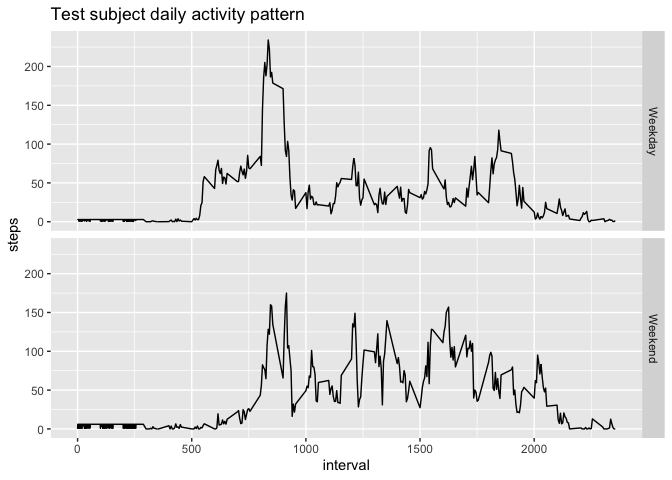

```r
#extract the date col. and return its day in the week

vect <- weekdays(data6$date)
temp <- seq_along(vect)

for (i in 1:length(vect)) {
  if (vect[i]== "Saturday"|vect[i]== "Sunday") {
    temp [i] <- "Weekend"
  }
  else {
    temp[i] <- "Weekday"
  }
}

cbind (data6, as.factor(temp)) -> data8
names (data8) <- c("steps", "date", "interval", "weekday")

data8 %>%
  select (-(date)) %>%
  group_by (interval, weekday) %>%
  summarize (steps = mean(steps)) -> data8

ggplot(data8, aes(interval, steps)) +
  geom_line()+
  facet_grid(rows = vars(weekday))+
  labs (title  = "Test subject daily activity pattern")
```

Voila! Here is the test subject’s daily activity pattern with imputed data! Thank you for reading my analysis!